# T03_LAB_Intercomparison_PabloCalatayud

[output not shown]

[output not shown]

```
# Minería de Datos (Master en Data Science, UIMP-UC)
```

```
## Técnicas de aprendizaje supervisado
```

```
### Practica de Intercomparación aplicada a datos meteorológicos
```

```
#### Santander Meteorology Group
```

```
En esta práctica haremos una intercomparación de varias de las técnicas de aprendizaje supervisado vistas a lo largo de la asignatura (CART, k-NN, GLMs y Random Forests). Por tanto, pretende ser un repaso general de cara al examen en el que el objetivo es tratar de entender las ventajas y limitaciones de las distintas técnicas para un caso de aplicación particular; la predicción de precipitación. La entrega consistirá en un notebook (Jupyter o R-Markdown), junto con el archivo html que éste genera. Ambos ficheros se entregarán a través del Moodle de la asignatura en la tarea correspondiente.
```

# Minería de Datos (Master en Data Science, UIMP-UC)

## Técnicas de aprendizaje supervisado

### Practica de Intercomparación aplicada a datos meteorológicos

#### Santander Meteorology Group

En esta práctica haremos una intercomparación de varias de las técnicas de aprendizaje supervisado vistas a lo largo de la asignatura (CART, k-NN, GLMs y Random Forests). Por tanto, pretende ser un repaso general de cara al examen en el que el objetivo es tratar de entender las ventajas y limitaciones de las distintas técnicas para un caso de aplicación particular; la predicción de precipitación. La entrega consistirá en un notebook (Jupyter o R-Markdown), junto con el archivo html que éste genera. Ambos ficheros se entregarán a través del Moodle de la asignatura en la tarea correspondiente.

```
## Conjunto de datos meteo
```

```
Comenzaremos cargando el dataset meteo, que ya ha sido utilizado en sesiones anteriores. Como ya sabéis, la variable objetivo en este dataset es la precipitation diaria en Lisboa durante el período 1979-2008, y para modelizar ésta se dispone de un conjunto de 8 variables meteorológicas predictoras que describen la circulación de larga escala definidas sobre un dominio geográfico que incluye 40 puntos sobre la Península Ibérica. (en total 8×40=320 variables explicativas). Las variables predictoras son:
```

```
* altura geopotencial en 500 hPa (Z500)
```

```
* temperatura del aire en 850 hPa, 700 hPa, 500 hPa (ta850, ta700 y ta500), y en superficie (tas)
```

```
* humedad específica del aire en 850 hPa y 500 hPa (hus850, hus500)
```

```
* presión a nivel del mar (psl)
```

```
Para agilizar los tiempos de cómputo, reduciremos la dimensionalidad del problema. Como ya se ha visto en sesiones anteriores, una alternativa para tal fin es el uso de PCs. Sin embargo, para no limitar la interpretabilidad de los resultados obtenidos con árboles, utilizaremos otra aproximación aquí. En concreto, optaremos por un análisis de correlaciones, en el que se calcula la correlación de Spearman entre nuestra variable objetivo y todas las variables predictoras disponibles. La asunción de partida es que cuanto más fuerte sea esta correlación, mayor es el vínculo físico entre predictando y predictor, y por tanto, más útil es la información que nos aporta ese predictor. Por tanto, este análisis nos permite descartar predictores poco relevantes. Siguiendo esta idea, calcularemos la correlación existente entre nuestro predictando y los 320 predictores, y eliminaremos aquellos con correlaciones entre -0.4 y 0.4. ¿Cuánto se ha reducido la dimensionalidad del problema?
```

## Conjunto de datos meteo

Comenzaremos cargando el dataset meteo, que ya ha sido utilizado en sesiones anteriores. Como ya sabéis, la variable objetivo en este dataset es la precipitation diaria en Lisboa durante el período 1979-2008, y para modelizar ésta se dispone de un conjunto de 8 variables meteorológicas predictoras que describen la circulación de larga escala definidas sobre un dominio geográfico que incluye 40 puntos sobre la Península Ibérica. (en total 8×40=320 variables explicativas). Las variables predictoras son:

- altura geopotencial en 500 hPa (Z500)
- temperatura del aire en 850 hPa, 700 hPa, 500 hPa (ta850, ta700 y ta500), y en superficie (tas)
- humedad específica del aire en 850 hPa y 500 hPa (hus850, hus500)
- presión a nivel del mar (psl)

Para agilizar los tiempos de cómputo, reduciremos la dimensionalidad del problema. Como ya se ha visto en sesiones anteriores, una alternativa para tal fin es el uso de PCs. Sin embargo, para no limitar la interpretabilidad de los resultados obtenidos con árboles, utilizaremos otra aproximación aquí. En concreto, optaremos por un análisis de correlaciones, en el que se calcula la correlación de Spearman entre nuestra variable objetivo y todas las variables predictoras disponibles. La asunción de partida es que cuanto más fuerte sea esta correlación, mayor es el vínculo físico entre predictando y predictor, y por tanto, más útil es la información que nos aporta ese predictor. Por tanto, este análisis nos permite descartar predictores poco relevantes. Siguiendo esta idea, calcularemos la correlación existente entre nuestro predictando y los 320 predictores, y eliminaremos aquellos con correlaciones entre -0.4 y 0.4. ¿Cuánto se ha reducido la dimensionalidad del problema?

```
#Cargamos las librerias correspondientes
```

```
library(caret)
```

```
library(class)
```

```
library(readr)
```

```
library(tree)
```

```
library(MASS)
```

```
## loading data
```

```
set.seed(0)
```

```
data = read.csv("./meteo.csv")
```

```
y = data[, 2]  # predictand
```

```
x = data[, -c(1,2)]  # predictors
```

```
## informed selection of predictors, based on a Spearman Correlation Analysis
```

```
r.xy = c()
```

```
for (ivar in 1:ncol(x)) {
```

```
  r.xy[ivar] = cor(y, x[, ivar], method = "spearman")
```

```
}
```

```
plot(r.xy, ylim = c(-1, 1), pch = 19, cex = 0.5,
```

```
     xlab = "predictor nº", ylab = "Spearman corr. with precip.")
```

```
grid()
```

```
legend("topleft",legend=c("Removed dimension","maintained dimension"),
```

```
       col=c("black","red"),
```

```
       pch=19,cex=1.5)
```

```
ind.sele = which(abs(r.xy) > 0.4)
```

```
points(ind.sele, r.xy[ind.sele], col = "red", cex = 0.5)
```

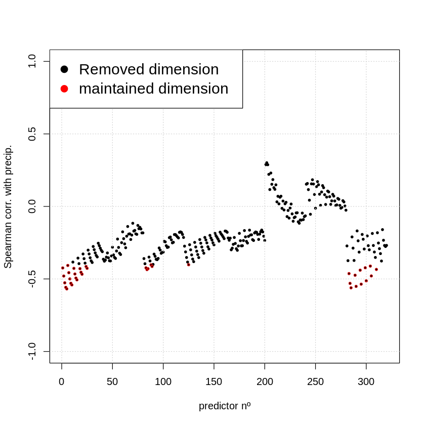

```
cat("Hemos reducido el numero de dimensiones de ", dim(x)[2]," a ",length(ind.sele), "para una correlacion de
```

```
Spearman fuera de rango (-0.4,0.4). " )
```

```
Hemos reducido el numero de dimensiones de  320  a  37 para una correlacion de
Spearman fuera de rango (-0.4,0.4).
```

```
df_0=data.frame(y,x[,ind.sele])
```

```
head(df_0,3)
```

```
tail(df_0,3)
```

```
cat("Numero de filas: ",dim(df_0)[1])
```

```
cat("\n")
```

```
cat("Numero de dimensiones: ",dim(x)[2])
```

A data.frame: 3 × 38

|  | y <dbl> | X1 <dbl> | X2 <dbl> | X3 <dbl> | X4 <dbl> | X5 <dbl> | X6 <dbl> | X7 <dbl> | X8 <dbl> | X9 <dbl> | ⋯ | X285 <dbl> | X289 <dbl> | X290 <dbl> | X294 <dbl> | X295 <dbl> | X299 <dbl> | X300 <dbl> | X304 <dbl> | X305 <dbl> | X310 <dbl> |
| --- | --- | --- | --- | --- | --- | --- | --- | --- | --- | --- | --- | --- | --- | --- | --- | --- | --- | --- | --- | --- | --- |
| 1 | 10.9 | 57042.96 | 56534.84 | 55884.40 | 55175.59 | 54458.21 | 56980.27 | 56460.59 | 55800.02 | 55051.15 | ⋯ | 101630.1 | 101951.2 | 101637.3 | 101851.9 | 101647.4 | 101771.5 | 101608.2 | 101599.4 | 101552.0 | 101491.4 |
| 2 | 0.6 | 56963.20 | 56493.45 | 55930.82 | 55340.20 | 54768.63 | 56856.57 | 56361.95 | 55776.76 | 55164.26 | ⋯ | 102157.7 | 102307.5 | 102222.2 | 102337.1 | 102366.5 | 102384.1 | 102581.7 | 102490.5 | 102765.8 | 102937.8 |
| 3 | 13.0 | 56522.59 | 55971.40 | 55304.34 | 54498.03 | 53725.15 | 56514.84 | 55977.71 | 55327.28 | 54569.78 | ⋯ | 100296.7 | 101128.8 | 100516.8 | 101360.8 | 100761.9 | 101570.8 | 101107.3 | 101841.0 | 101526.0 | 101967.7 |

A data.frame: 3 × 38

|  | y <dbl> | X1 <dbl> | X2 <dbl> | X3 <dbl> | X4 <dbl> | X5 <dbl> | X6 <dbl> | X7 <dbl> | X8 <dbl> | X9 <dbl> | ⋯ | X285 <dbl> | X289 <dbl> | X290 <dbl> | X294 <dbl> | X295 <dbl> | X299 <dbl> | X300 <dbl> | X304 <dbl> | X305 <dbl> | X310 <dbl> |
| --- | --- | --- | --- | --- | --- | --- | --- | --- | --- | --- | --- | --- | --- | --- | --- | --- | --- | --- | --- | --- | --- |
| 10956 | 2.5 | 55848.00 | 55610.50 | 55357.88 | 55078.38 | 54772.69 | 55865.19 | 55636.57 | 55391.69 | 55139.63 | ⋯ | 101361.3 | 101737.5 | 101581.1 | 101979.0 | 101690.8 | 102073.0 | 101753.8 | 102135.1 | 101837.2 | 101977.8 |
| 10957 | 12.9 | 56038.79 | 55867.86 | 55689.86 | 55530.17 | 55383.23 | 56216.73 | 56039.92 | 55869.23 | 55695.67 | ⋯ | 101688.4 | 101978.1 | 101891.6 | 102235.0 | 102035.8 | 102377.2 | 102180.2 | 102489.3 | 102288.5 | 102360.0 |
| 10958 | 5.3 | 55494.88 | 55280.62 | 55125.25 | 55033.56 | 55016.19 | 55726.19 | 55547.69 | 55407.06 | 55323.69 | ⋯ | 101223.4 | 101639.5 | 101521.0 | 101991.9 | 101677.9 | 102150.3 | 101812.8 | 102305.4 | 102004.7 | 102156.4 |

```
Numero de filas:  10958
Numero de dimensiones:  320
```

```
Para simplificar aún más los cálculos, nos limitaremos a los primeros 5000 días del dataset. Como siempre, consideraremos una partición de la muestra en dos subconjuntos independientes, train y test, escogidos aleatoriamente (75% para entrenar y 25% para validar).
```

```
## Árboles de clasificación y regresión (2.5 puntos)
```

```
Como ya hemos visto en sesiones anteriores, tendremos que crear dos modelos independientes, uno para la clasificación del evento binario lluvia/no lluvia y otro para el evento continuo cantidad de lluvia. Nos centramos en primer lugar en la clasificación lluvia/no lluvia. Para ello, tenemos que crear la variable binaria ocurrencia de precipitación (considera un umbral de 1 mm) y construir el dataframe asociado al problema.
```

```
A continuación construiremos el árbol completo (usa la función tree). ¿Cuántos nodos terminales obtienes? ¿Qué variables predictoras dan lugar a las primeras subdivisiones del árbol?
```

Para simplificar aún más los cálculos, nos limitaremos a los primeros 5000 días del dataset. Como siempre, consideraremos una partición de la muestra en dos subconjuntos independientes, train y test, escogidos aleatoriamente (75% para entrenar y 25% para validar).

## Árboles de clasificación y regresión (2.5 puntos)

Como ya hemos visto en sesiones anteriores, tendremos que crear dos modelos independientes, uno para la clasificación del evento binario lluvia/no lluvia y otro para el evento continuo cantidad de lluvia. Nos centramos en primer lugar en la clasificación lluvia/no lluvia. Para ello, tenemos que crear la variable binaria ocurrencia de precipitación (considera un umbral de 1 mm) y construir el dataframe asociado al problema.

A continuación construiremos el árbol completo (usa la función tree). ¿Cuántos nodos terminales obtienes? ¿Qué variables predictoras dan lugar a las primeras subdivisiones del árbol?

```
#Para simplificar aún más los cálculos, nos limitaremos a los primeros 5000 días del dataset.
```

```
#Como siempre, consideraremos una partición de la muestra en dos subconjuntos independientes,
```

```
#train y test, escogidos aleatoriamente (75% para entrenar y 25% para validar)
```

```
# keeping only 5000 days for this example
```

```
n = 5000
```

```
y = y[1:n]
```

```
x = x[1:n, ind.sele]
```

```
# train/test partition
```

```
indtrain = sample(1:n, round(0.75*n))
```

```
indtest = setdiff(1:n, indtrain)
```

```
### 1.1. Arbol de clasificación
```

### 1.1. Arbol de clasificación

```
# binary occurrence
```

```
occ = y
```

```
occ[which(y < 1)] = 0  # dry day
```

```
occ[which(y >= 1)] = 1  # rainy day
```

```
# dataframe for occurrence
```

```
df.occ = data.frame(y.occ = as.factor(occ), predictors = x)
```

```
head(df.occ,3)
```

```
tail(df.occ,3)
```

A data.frame: 3 × 38

|  | y.occ <fct> | predictors.X1 <dbl> | predictors.X2 <dbl> | predictors.X3 <dbl> | predictors.X4 <dbl> | predictors.X5 <dbl> | predictors.X6 <dbl> | predictors.X7 <dbl> | predictors.X8 <dbl> | predictors.X9 <dbl> | ⋯ | predictors.X285 <dbl> | predictors.X289 <dbl> | predictors.X290 <dbl> | predictors.X294 <dbl> | predictors.X295 <dbl> | predictors.X299 <dbl> | predictors.X300 <dbl> | predictors.X304 <dbl> | predictors.X305 <dbl> | predictors.X310 <dbl> |
| --- | --- | --- | --- | --- | --- | --- | --- | --- | --- | --- | --- | --- | --- | --- | --- | --- | --- | --- | --- | --- | --- |
| 1 | 1 | 57042.96 | 56534.84 | 55884.40 | 55175.59 | 54458.21 | 56980.27 | 56460.59 | 55800.02 | 55051.15 | ⋯ | 101630.1 | 101951.2 | 101637.3 | 101851.9 | 101647.4 | 101771.5 | 101608.2 | 101599.4 | 101552.0 | 101491.4 |
| 2 | 0 | 56963.20 | 56493.45 | 55930.82 | 55340.20 | 54768.63 | 56856.57 | 56361.95 | 55776.76 | 55164.26 | ⋯ | 102157.7 | 102307.5 | 102222.2 | 102337.1 | 102366.5 | 102384.1 | 102581.7 | 102490.5 | 102765.8 | 102937.8 |
| 3 | 1 | 56522.59 | 55971.40 | 55304.34 | 54498.03 | 53725.15 | 56514.84 | 55977.71 | 55327.28 | 54569.78 | ⋯ | 100296.7 | 101128.8 | 100516.8 | 101360.8 | 100761.9 | 101570.8 | 101107.3 | 101841.0 | 101526.0 | 101967.7 |

A data.frame: 3 × 38

|  | y.occ <fct> | predictors.X1 <dbl> | predictors.X2 <dbl> | predictors.X3 <dbl> | predictors.X4 <dbl> | predictors.X5 <dbl> | predictors.X6 <dbl> | predictors.X7 <dbl> | predictors.X8 <dbl> | predictors.X9 <dbl> | ⋯ | predictors.X285 <dbl> | predictors.X289 <dbl> | predictors.X290 <dbl> | predictors.X294 <dbl> | predictors.X295 <dbl> | predictors.X299 <dbl> | predictors.X300 <dbl> | predictors.X304 <dbl> | predictors.X305 <dbl> | predictors.X310 <dbl> |
| --- | --- | --- | --- | --- | --- | --- | --- | --- | --- | --- | --- | --- | --- | --- | --- | --- | --- | --- | --- | --- | --- |
| 4998 | 0 | 57693.77 | 57639.89 | 57513.83 | 57299.02 | 57000.71 | 57726.64 | 57653.21 | 57547.83 | 57361.33 | ⋯ | 101883.6 | 101884.9 | 101884.9 | 101834.0 | 101861.0 | 101871.0 | 101868.3 | 101914.8 | 101913.3 | 101995.5 |
| 4999 | 0 | 57590.49 | 57389.05 | 57113.18 | 56779.55 | 56404.43 | 57559.30 | 57398.87 | 57172.87 | 56879.68 | ⋯ | 102135.8 | 102040.9 | 102095.8 | 101889.0 | 102068.7 | 101838.0 | 102025.4 | 101824.1 | 101959.8 | 101866.1 |
| 5000 | 0 | 57060.24 | 56702.37 | 56323.37 | 56108.55 | 56035.80 | 57139.55 | 56776.87 | 56362.12 | 56101.30 | ⋯ | 102436.3 | 102037.6 | 102340.4 | 101938.1 | 102277.2 | 101891.2 | 102231.9 | 101887.3 | 102199.0 | 102181.5 |

```
## complete tree (based on training dataset)
```

```
library(tree)
```

```
t.occ = tree(y.occ ~., df.occ, subset = indtrain,
```

```
     mincut = 1, minsize = 2, mindev = 0)
```

```
plot(t.occ); text(t.occ, pretty = F)
```

```
summary(t.occ)
```

```
Classification tree:
tree(formula = y.occ ~ ., data = df.occ, subset = indtrain, mincut = 1,
    minsize = 2, mindev = 0)
Variables actually used in tree construction:
 [1] "predictors.X285" "predictors.X284" "predictors.X25"  "predictors.X1"
 [5] "predictors.X83"  "predictors.X84"  "predictors.X5"   "predictors.X304"
 [9] "predictors.X300" "predictors.X20"  "predictors.X10"  "predictors.X8"
[13] "predictors.X283" "predictors.X89"  "predictors.X13"  "predictors.X14"
[17] "predictors.X15"  "predictors.X88"  "predictors.X290" "predictors.X24"
[21] "predictors.X299" "predictors.X3"   "predictors.X18"  "predictors.X305"
[25] "predictors.X2"   "predictors.X4"   "predictors.X289" "predictors.X310"
[29] "predictors.X294" "predictors.X295" "predictors.X85"  "predictors.X6"
[33] "predictors.X9"   "predictors.X19"  "predictors.X125" "predictors.X12"
Number of terminal nodes:  292
Residual mean deviance:  0 = 0 / 3458
Misclassification error rate: 0 = 0 / 3750
```

[figure not shown]

```
### 1.2. A continuación construiremos el árbol completo (usa la función tree). ¿Cuántos nodos terminales obtienes? ¿Qué variables predictoras dan lugar a las primeras subdivisiones del árbol?
```

### 1.2. A continuación construiremos el árbol completo (usa la función tree). ¿Cuántos nodos terminales obtienes? ¿Qué variables predictoras dan lugar a las primeras subdivisiones del árbol?

```
#Con el arbol completo obtenemos 292 nodos terminales.
```

```
#Las variables predictoras que dan lugar a las primeras subdivisiones del arbol son:
```

[output not shown]

```
#
```

```
Para simplificar este árbol tan complejo tendremos que podarlo adecuadamente. Utiliza una cross-validación con un 10-fold para encontrar el número de nodos terminales del árbol óptimo. ¿Cuál es este número? ¿Qué predictores aparecen como los más importantes?
```

Para simplificar este árbol tan complejo tendremos que podarlo adecuadamente. Utiliza una cross-validación con un 10-fold para encontrar el número de nodos terminales del árbol óptimo. ¿Cuál es este número? ¿Qué predictores aparecen como los más importantes?

```
## 10-fold cross-validation for determining optimum number of leaves
```

```
t.occ.cv = cv.tree(t.occ, K = 10)
```

```
plot(t.occ.cv$size, t.occ.cv$dev, type = "b", xlim = c(1, 30),
```

```
    xlab = "no. of leaves", ylab = "deviance")  # deviance as a function of number of leaves
```

```
grid()
```

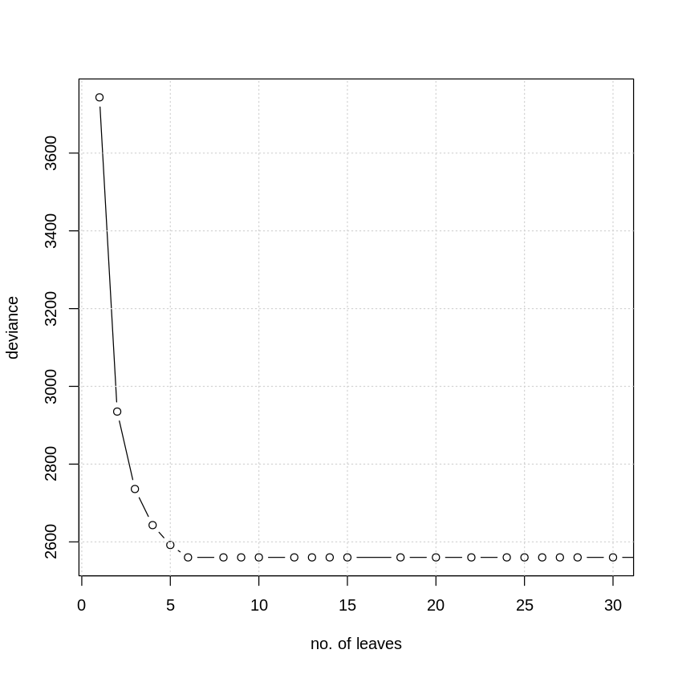

```
# Un arbol con 6 hojas puede ser un arbol optimo. Ya que a partir de 6 hojas la deviance se estanca y se deja
```

```
#de mejorar
```

```
#En este caso se ha establecido el optimo en función del numero de nodos terminales.
```

```
#Otro parametro a partir del cual se podria haber establecido el arbol optimo es el número de niveles
```

```
#del arbol
```

```
# pruning
```

```
t.occ.opt = prune.tree(t.occ, best = 6)
```

```
plot(t.occ.opt); text(t.occ.opt)
```

```
summary(t.occ.opt)
```

```
Classification tree:
snip.tree(tree = t.occ, nodes = c(11L, 4L, 10L, 14L, 6L))
Variables actually used in tree construction:
[1] "predictors.X285" "predictors.X284" "predictors.X5"   "predictors.X4"
[5] "predictors.X2"
Number of terminal nodes:  6
Residual mean deviance:  0.6485 = 2428 / 3744
Misclassification error rate: 0.1389 = 521 / 3750
```

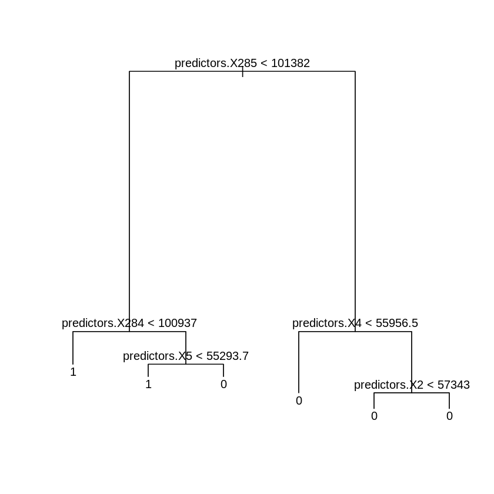

```
#En este caso las variables consideradas son:
```

```
#     X285, X284, X5, X4, X2
```

```
## occurrence prediction for test
```

```
# tree fitted with 'tree'
```

```
pred.t.occ = predict(t.occ.opt, df.occ[indtest, ], type = "class")
```

```
str(pred.t.occ)
```

```
## validation
```

```
# accuracy
```

```
acc.t_class_tree = sum(diag(table(occ[indtest], pred.t.occ))) / length(indtest)
```

```
cat("Accuracy for test:",acc.t_class_tree)
```

```
 Factor w/ 2 levels "0","1": 1 2 1 1 1 1 2 2 2 2 ...
Accuracy for test: 0.8552
```

```
Utiliza este árbol óptimo para predecir en el test. Guarda las predicciones.
```

```
Una vez obtenidas las predicciones de ocurrencia pasaremos a estimar la cantidad de precipitación. Primero creamos el dataset correspondiente.
```

```
A continuación construiremos dos árboles, uno entrenado sobre todo el conjunto de train y otro entrenado sólo sobre los días de lluvia (en el train). Empezamos por el primero de estos árboles. Construye el árbol completo ¿Cuántos nodos terminales obtienes? ¿Qué variables predictoras dan lugar a las primeras subdivisiones del árbol? ¿Son las mismas que para el caso de la ocurrencia?
```

Utiliza este árbol óptimo para predecir en el test. Guarda las predicciones.

Una vez obtenidas las predicciones de ocurrencia pasaremos a estimar la cantidad de precipitación. Primero creamos el dataset correspondiente.

A continuación construiremos dos árboles, uno entrenado sobre todo el conjunto de train y otro entrenado sólo sobre los días de lluvia (en el train). Empezamos por el primero de estos árboles. Construye el árbol completo ¿Cuántos nodos terminales obtienes? ¿Qué variables predictoras dan lugar a las primeras subdivisiones del árbol? ¿Son las mismas que para el caso de la ocurrencia?

```
### 1.3. Arbol de regresión
```

### 1.3. Arbol de regresión

```
#DataSet con precipitación no binaria formado por train
```

```
df_1=data.frame(y, predictors = x)
```

```
names(df_1)[1]= "lluvia1"
```

```
head(df_1,3)
```

```
tail(df_1,3)
```

A data.frame: 3 × 38

|  | lluvia1 <dbl> | predictors.X1 <dbl> | predictors.X2 <dbl> | predictors.X3 <dbl> | predictors.X4 <dbl> | predictors.X5 <dbl> | predictors.X6 <dbl> | predictors.X7 <dbl> | predictors.X8 <dbl> | predictors.X9 <dbl> | ⋯ | predictors.X285 <dbl> | predictors.X289 <dbl> | predictors.X290 <dbl> | predictors.X294 <dbl> | predictors.X295 <dbl> | predictors.X299 <dbl> | predictors.X300 <dbl> | predictors.X304 <dbl> | predictors.X305 <dbl> | predictors.X310 <dbl> |
| --- | --- | --- | --- | --- | --- | --- | --- | --- | --- | --- | --- | --- | --- | --- | --- | --- | --- | --- | --- | --- | --- |
| 1 | 10.9 | 57042.96 | 56534.84 | 55884.40 | 55175.59 | 54458.21 | 56980.27 | 56460.59 | 55800.02 | 55051.15 | ⋯ | 101630.1 | 101951.2 | 101637.3 | 101851.9 | 101647.4 | 101771.5 | 101608.2 | 101599.4 | 101552.0 | 101491.4 |
| 2 | 0.6 | 56963.20 | 56493.45 | 55930.82 | 55340.20 | 54768.63 | 56856.57 | 56361.95 | 55776.76 | 55164.26 | ⋯ | 102157.7 | 102307.5 | 102222.2 | 102337.1 | 102366.5 | 102384.1 | 102581.7 | 102490.5 | 102765.8 | 102937.8 |
| 3 | 13.0 | 56522.59 | 55971.40 | 55304.34 | 54498.03 | 53725.15 | 56514.84 | 55977.71 | 55327.28 | 54569.78 | ⋯ | 100296.7 | 101128.8 | 100516.8 | 101360.8 | 100761.9 | 101570.8 | 101107.3 | 101841.0 | 101526.0 | 101967.7 |

A data.frame: 3 × 38

|  | lluvia1 <dbl> | predictors.X1 <dbl> | predictors.X2 <dbl> | predictors.X3 <dbl> | predictors.X4 <dbl> | predictors.X5 <dbl> | predictors.X6 <dbl> | predictors.X7 <dbl> | predictors.X8 <dbl> | predictors.X9 <dbl> | ⋯ | predictors.X285 <dbl> | predictors.X289 <dbl> | predictors.X290 <dbl> | predictors.X294 <dbl> | predictors.X295 <dbl> | predictors.X299 <dbl> | predictors.X300 <dbl> | predictors.X304 <dbl> | predictors.X305 <dbl> | predictors.X310 <dbl> |
| --- | --- | --- | --- | --- | --- | --- | --- | --- | --- | --- | --- | --- | --- | --- | --- | --- | --- | --- | --- | --- | --- |
| 4998 | 0 | 57693.77 | 57639.89 | 57513.83 | 57299.02 | 57000.71 | 57726.64 | 57653.21 | 57547.83 | 57361.33 | ⋯ | 101883.6 | 101884.9 | 101884.9 | 101834.0 | 101861.0 | 101871.0 | 101868.3 | 101914.8 | 101913.3 | 101995.5 |
| 4999 | 0 | 57590.49 | 57389.05 | 57113.18 | 56779.55 | 56404.43 | 57559.30 | 57398.87 | 57172.87 | 56879.68 | ⋯ | 102135.8 | 102040.9 | 102095.8 | 101889.0 | 102068.7 | 101838.0 | 102025.4 | 101824.1 | 101959.8 | 101866.1 |
| 5000 | 0 | 57060.24 | 56702.37 | 56323.37 | 56108.55 | 56035.80 | 57139.55 | 56776.87 | 56362.12 | 56101.30 | ⋯ | 102436.3 | 102037.6 | 102340.4 | 101938.1 | 102277.2 | 101891.2 | 102231.9 | 101887.3 | 102199.0 | 102181.5 |

```
#Creamos el arbol completo, el dataset df_1 y el subset = train
```

```
tree.compt_train_reg = tree(lluvia1 ~ ., df_1, subset = indtrain, mincut=1, minsize=2, mindev=0)
```

```
summary(tree.compt_train_reg)
```

```
plot(tree.compt_train_reg)
```

```
text(tree.compt_train_reg)
```

```
Regression tree:
tree(formula = lluvia1 ~ ., data = df_1, subset = indtrain, mincut = 1,
    minsize = 2, mindev = 0)
Number of terminal nodes:  949
Residual mean deviance:  0.002668 = 7.474 / 2801
Distribution of residuals:
      Min.    1st Qu.     Median       Mean    3rd Qu.       Max.
-0.2500000 -0.0030610 -0.0003306  0.0000000  0.0000000  0.2982000
```

[figure not shown]

```
tree.compt_train_reg
```

```
#Para observar mejor cuales son las variables que mas influyen en el tree
```

[output not shown]

[output cut: 1845 more lines]

```
                                        1048090) predictors.X1 < 57189.3 1 0.000e+00 6.000e-01 *
                                        1048091) predictors.X1 > 57189.3 1 0.000e+00 0.000e+00 *
                                     262023) predictors.X5 > 56419.3 324 7.951e-02 1.235e-03 *
                                32753) predictors.X7 > 57587.3 1 0.000e+00 8.000e-01 *
                              16377) predictors.X2 > 57324.5 1 0.000e+00 1.000e+00 *
                             8189) predictors.X8 > 57430 9 2.418e+01 7.778e-01
                              16378) predictors.X7 < 57364.2 1 0.000e+00 5.100e+00 *
                              16379) predictors.X7 > 57364.2 8 3.159e+00 2.375e-01
                                32758) predictors.X6 < 57818.1 7 0.000e+00 0.000e+00 *
                                32759) predictors.X6 > 57818.1 1 0.000e+00 1.900e+00 *
                           4095) predictors.X2 > 57325.9 627 3.990e-01 1.276e-03
                             8190) predictors.X84 < 275.093 22 3.436e-01 2.727e-02
                              16380) predictors.X12 < 58014.5 21 0.000e+00 0.000e+00 *
                              16381) predictors.X12 > 58014.5 1 0.000e+00 6.000e-01 *
                             8191) predictors.X84 > 275.093 605 3.993e-02 3.306e-04 *
```

```
# ¿Cuántos nodos terminales obtienes? ¿Qué variables predictoras dan lugar a las primeras subdivisiones del árbol?
```

```
# ¿Son las mismas que para el caso de la ocurrencia?
```

```
#
```

```
#
```

```
#El arbol completo tiene 949 nodos terminales
```

```
#
```

```
#En este caso lsa variables mas importantes son
```

[output not shown]

```
#
```

```
#En el caso de la occurencia las variablesmas importantes eran
```

[output not shown]

```
#
```

[output not shown]

```
#
```

```
Al igual que hicimos para el caso de la ocurrencia, tendremos que podar este árbol tan complejo. Utiliza una cross-validación con un 10-fold para encontrar el número de nodos terminales del árbol óptimo. ¿Cuál es este número? ¿Qué predictores aparecen como los más importantes?
```

Al igual que hicimos para el caso de la ocurrencia, tendremos que podar este árbol tan complejo. Utiliza una cross-validación con un 10-fold para encontrar el número de nodos terminales del árbol óptimo. ¿Cuál es este número? ¿Qué predictores aparecen como los más importantes?

```
## 10-fold cross-validation of the complete tree
```

```
t.full.cv = cv.tree(tree.compt_train_reg, K = 10)
```

```
plot(t.full.cv$size, t.full.cv$dev, type = "o", pch = 19, lty = 1,
```

```
     xlab = "no. of leaves", ylab = "deviance",
```

```
     main = "10-fold CV tree", xlim = c(0, 15))
```

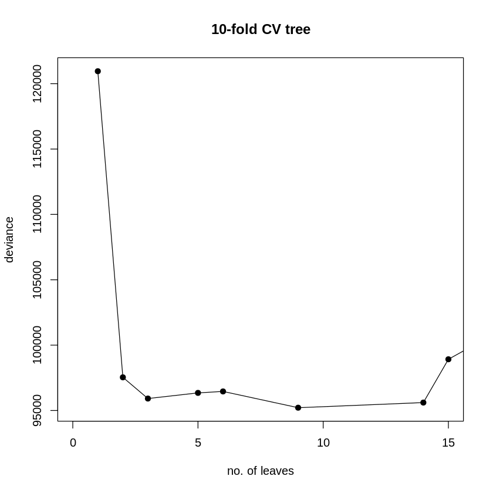

[output not shown]

[output not shown]

```
prune.opt_rain_reg = prune.tree(tree.compt_train_reg, best = 6)
```

```
plot(prune.opt_rain_reg)
```

```
title(main = "Prunned tree (forced to 6 leaves)")
```

```
text(prune.opt_rain_reg, col = "red")
```

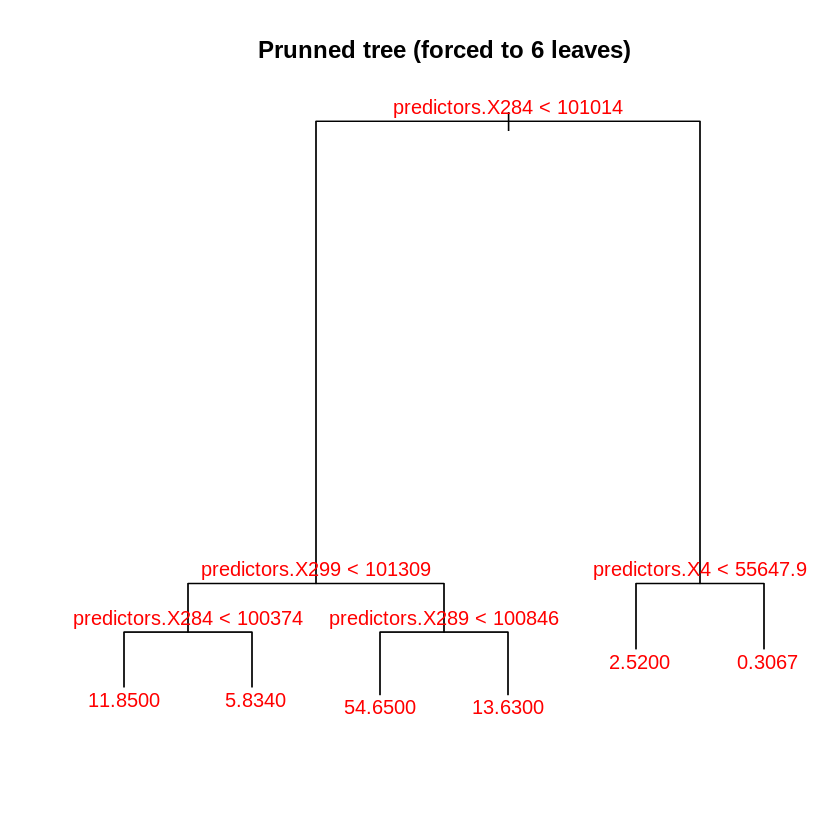

```
yhat <- predict(prune.opt_rain_reg, newdata = df_1[indtest, ])
```

```
prune.opt_rain_reg_test <- df_1[indtest, "lluvia1"]
```

```
plot(yhat, prune.opt_rain_reg_test)
```

```
title(main = "Pruned tree - test set")
```

```
rmse.test_reg1_test <- sqrt(mean((yhat - prune.opt_rain_reg_test)^2))
```

```
mtext(text = paste("RMSE =", round(rmse.test_reg1_test, 3)), side = 3)
```

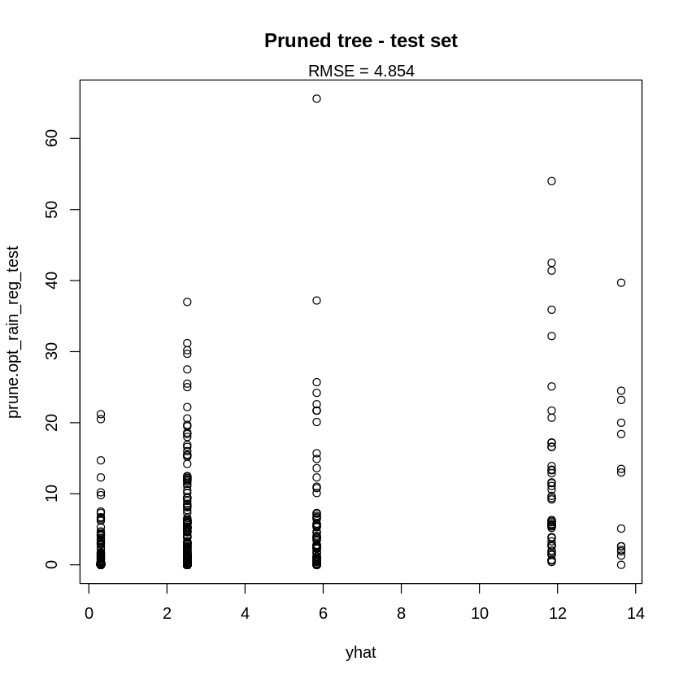

```
#Al ser un caso de regresion en vez de un caso de clasificacion el error se mide en RMSE en vez de en
```

```
#la accuracy de alguno de los valores de la matriz de confusion
```

```
cat("Error del árbol optimo en regresion para el dataSet df_1 en el subset de test es:",rmse.test_reg1_test)
```

```
Error del árbol optimo en regresion para el dataSet df_1 en el subset de test es: 4.853716
```

```
Utiliza el árbol óptimo que acabas de encontrar para predecir en el test, y conserva la predicción obtenida.
```

```
Repite el mismo proceso para el segundo árbol de regresión (el que sólo se entrena sobre los días de lluvia en el train).
```

```
Obtén las dos series predichas completas para el test (la secuencia lluvia/no lluvia será la misma en las dos) y valida tus resultados en función de las siguiente métricas:
```

```
Para la parte binaria lluvia/no lluvia: Accuracy.
```

```
Para la serie completa: RMSE, correlación de Spearman y ratio de varianzas.
```

```
Pregunta: ¿Cuál de los dos árboles da mejores resultados? ¿Por qué?
```

Utiliza el árbol óptimo que acabas de encontrar para predecir en el test, y conserva la predicción obtenida.

Repite el mismo proceso para el segundo árbol de regresión (el que sólo se entrena sobre los días de lluvia en el train).

Obtén las dos series predichas completas para el test (la secuencia lluvia/no lluvia será la misma en las dos) y valida tus resultados en función de las siguiente métricas:

Para la parte binaria lluvia/no lluvia: Accuracy. Para la serie completa: RMSE, correlación de Spearman y ratio de varianzas. Pregunta: ¿Cuál de los dos árboles da mejores resultados? ¿Por qué?

```
#Cogemos solamente los valores de lluvia positivo
```

```
ind.lluvia=which(y >= 1)  # rainy day
```

```
n2=length(ind.lluvia)
```

```
#Construyo el train
```

```
indtrain2 = sample(1:n2, round(0.75*n2))
```

```
#Construyo el test
```

```
indtest2 = setdiff(1:n2, indtrain2)
```

```
#DataSet con precipitación no binaria formado por train en los dias de lluvia
```

```
df_2=data.frame(y[ind.lluvia],predictors = x[ind.lluvia,])
```

```
names(df_2)[1]= "lluvia2"
```

```
#
```

```
head(df_2,3)
```

```
tail(df_2,3)
```

A data.frame: 3 × 38

|  | lluvia2 <dbl> | predictors.X1 <dbl> | predictors.X2 <dbl> | predictors.X3 <dbl> | predictors.X4 <dbl> | predictors.X5 <dbl> | predictors.X6 <dbl> | predictors.X7 <dbl> | predictors.X8 <dbl> | predictors.X9 <dbl> | ⋯ | predictors.X285 <dbl> | predictors.X289 <dbl> | predictors.X290 <dbl> | predictors.X294 <dbl> | predictors.X295 <dbl> | predictors.X299 <dbl> | predictors.X300 <dbl> | predictors.X304 <dbl> | predictors.X305 <dbl> | predictors.X310 <dbl> |
| --- | --- | --- | --- | --- | --- | --- | --- | --- | --- | --- | --- | --- | --- | --- | --- | --- | --- | --- | --- | --- | --- |
| 1 | 10.9 | 57042.96 | 56534.84 | 55884.40 | 55175.59 | 54458.21 | 56980.27 | 56460.59 | 55800.02 | 55051.15 | ⋯ | 101630.1 | 101951.2 | 101637.3 | 101851.9 | 101647.4 | 101771.5 | 101608.2 | 101599.4 | 101552.0 | 101491.4 |
| 3 | 13.0 | 56522.59 | 55971.40 | 55304.34 | 54498.03 | 53725.15 | 56514.84 | 55977.71 | 55327.28 | 54569.78 | ⋯ | 100296.7 | 101128.8 | 100516.8 | 101360.8 | 100761.9 | 101570.8 | 101107.3 | 101841.0 | 101526.0 | 101967.7 |
| 6 | 1.2 | 54221.86 | 54220.24 | 54328.55 | 54772.49 | 55251.11 | 54391.11 | 54345.93 | 54284.05 | 54525.99 | ⋯ | 102389.9 | 102054.1 | 102339.8 | 102220.9 | 102367.2 | 102249.9 | 102394.1 | 102287.2 | 102379.8 | 102404.8 |

A data.frame: 3 × 38

|  | lluvia2 <dbl> | predictors.X1 <dbl> | predictors.X2 <dbl> | predictors.X3 <dbl> | predictors.X4 <dbl> | predictors.X5 <dbl> | predictors.X6 <dbl> | predictors.X7 <dbl> | predictors.X8 <dbl> | predictors.X9 <dbl> | ⋯ | predictors.X285 <dbl> | predictors.X289 <dbl> | predictors.X290 <dbl> | predictors.X294 <dbl> | predictors.X295 <dbl> | predictors.X299 <dbl> | predictors.X300 <dbl> | predictors.X304 <dbl> | predictors.X305 <dbl> | predictors.X310 <dbl> |
| --- | --- | --- | --- | --- | --- | --- | --- | --- | --- | --- | --- | --- | --- | --- | --- | --- | --- | --- | --- | --- | --- |
| 4929 | 1.4 | 57378.31 | 57020.81 | 56574.93 | 56086.00 | 55691.81 | 57410.06 | 57097.75 | 56725.06 | 56325.75 | ⋯ | 101343.3 | 101618.4 | 101463.2 | 101461.1 | 101520.6 | 101431.0 | 101523.1 | 101425.8 | 101453.5 | 101389.1 |
| 4988 | 2.6 | 57975.07 | 57718.57 | 57406.82 | 56964.57 | 56385.32 | 58013.13 | 57783.95 | 57502.26 | 57130.20 | ⋯ | 101056.0 | 101724.5 | 101207.5 | 101666.3 | 101307.3 | 101590.3 | 101360.9 | 101499.2 | 101364.0 | 101413.9 |
| 4991 | 1.3 | 57509.55 | 57209.18 | 56779.80 | 56160.18 | 55218.24 | 57496.37 | 57199.24 | 56773.99 | 56161.05 | ⋯ | 100754.4 | 101324.3 | 100749.8 | 101347.6 | 100756.8 | 101361.2 | 100798.7 | 101251.0 | 100894.3 | 100987.6 |

```
cat("Tamaño del dataSet solo con los dias de lluvia:",dim(df_2)[1] )
```

```
cat("\n")
```

```
cat("Tamaño del dataSet train:",length(indtrain2) )
```

```
cat("\n")
```

```
cat("Tamaño del dataSet test:",length(indtest2) )
```

```
Tamaño del dataSet solo con los dias de lluvia: 1011
Tamaño del dataSet train: 758
Tamaño del dataSet test: 253
```

```
#Creamos el arbol completo, el dataset df_2 y el subset = train
```

```
tree.compt_train_reg_df2 = tree(lluvia2 ~ ., df_2,
```

```
                                subset = indtrain2, mincut=1, minsize=2, mindev=0)
```

```
summary(tree.compt_train_reg_df2)
```

```
plot(tree.compt_train_reg_df2)
```

```
text(tree.compt_train_reg_df2)
```

```
Regression tree:
tree(formula = lluvia2 ~ ., data = df_2, subset = indtrain2,
    mincut = 1, minsize = 2, mindev = 0)
Number of terminal nodes:  597
Residual mean deviance:  0.0154 = 2.48 / 161
Distribution of residuals:
   Min. 1st Qu.  Median    Mean 3rd Qu.    Max.
   -0.2     0.0     0.0     0.0     0.0     0.2
```

[figure not shown]

```
tree.compt_train_reg_df2
```

```
#Para observar mejor cuales son las variables que mas influyen en el tree
```

```
node), split, n, deviance, yval
      * denotes terminal node

      1) root 758 7.358e+04  9.040
        2) predictors.X284 < 100993 296 3.495e+04 11.810
          4) predictors.X85 < 264.958 71 2.202e+03  5.746
            8) predictors.X4 < 53669.1 66 1.544e+03  5.114
             16) predictors.X304 < 100872 52 5.729e+02  4.185
               32) predictors.X83 < 268.992 49 4.256e+02  3.792
                 64) predictors.X305 < 100417 37 1.739e+02  3.208
                  128) predictors.X300 < 99310.5 8 4.840e+01  5.962
                    256) predictors.X299 < 99496.4 5 1.235e+01  4.380
                      512) predictors.X4 < 51245.7 1 0.000e+00  1.500 *
                      513) predictors.X4 > 51245.7 4 1.980e+00  5.100
                       1026) predictors.X10 < 51227.9 1 0.000e+00  3.900 *
                       1027) predictors.X10 > 51227.9 3 6.000e-02  5.500 *
                    257) predictors.X299 > 99496.4 3 2.660e+00  8.600
                      514) predictors.X1 < 54927.4 2 5.000e-01  8.000
                       1028) predictors.X1 < 54301.2 1 0.000e+00  7.500 *
                       1029) predictors.X1 > 54301.2 1 0.000e+00  8.500 *
                      515) predictors.X1 > 54927.4 1 0.000e+00  9.800 *
                  129) predictors.X300 > 99310.5 29 4.811e+01  2.448
                    258) predictors.X284 < 100820 28 3.648e+01  2.329
                      516) predictors.X3 < 52471 1 0.000e+00  5.000 *
                      517) predictors.X3 > 52471 27 2.908e+01  2.230
                       1034) predictors.X24 < 53519.7 19 2.167e+01  2.516
                         2068) predictors.X89 < 263.974 17 1.423e+01  2.306
                           4136) predictors.X84 < 263.373 13 8.880e+00  2.600
                             8272) predictors.X283 < 100487 7 2.174e+00  2.029
                              16544) predictors.X9 < 52572 5 6.400e-01  2.300
                                33088) predictors.X18 < 53049.9 3 8.667e-02  2.567
                                  66176) predictors.X1 < 54353.1 2 5.000e-03  2.450 *
                                  66177) predictors.X1 > 54353.1 1 0.000e+00  2.800 *
                                33089) predictors.X18 > 53049.9 2 2.000e-02  1.900 *
                              16545) predictors.X9 > 52572 2 2.450e-01  1.350
                                33090) predictors.X1 < 53448.5 1 0.000e+00  1.000 *
                                33091) predictors.X1 > 53448.5 1 0.000e+00  1.700 *
                             8273) predictors.X283 > 100487 6 1.753e+00  3.267
                              16546) predictors.X83 < 263.522 2 2.450e-01  2.650
                                33092) predictors.X1 < 53886.2 1 0.000e+00  2.300 *
```

[output cut: 1141 more lines]

```
                       2041) predictors.X1 > 56880.1 1 0.000e+00  4.100 *
                     1021) predictors.X7 > 56618.4 3 0.000e+00  1.000 *
                    511) predictors.X12 > 56786.5 10 4.956e+00  3.520
                     1022) predictors.X310 < 102180 7 2.780e+00  3.800
                       2044) predictors.X310 < 102143 6 8.083e-01  3.583
                         4088) predictors.X3 < 56656.1 2 8.000e-02  4.000
                           8176) predictors.X6 < 56955.6 1 0.000e+00  4.200 *
                           8177) predictors.X6 > 56955.6 1 0.000e+00  3.800 *
                         4089) predictors.X3 > 56656.1 4 2.075e-01  3.375
                           8178) predictors.X1 < 57607.6 3 2.000e-02  3.500 *
                           8179) predictors.X1 > 57607.6 1 0.000e+00  3.000 *
                       2045) predictors.X310 > 102143 1 0.000e+00  5.100 *
                     1023) predictors.X310 > 102180 3 3.467e-01  2.867
                       2046) predictors.X2 < 56839.3 1 0.000e+00  2.400 *
                       2047) predictors.X2 > 56839.3 2 2.000e-02  3.100 *
```

```
# ¿Cuántos nodos terminales obtienes? ¿Qué variables predictoras dan lugar a las primeras subdivisiones del árbol?
```

```
# ¿Son las mismas que para el caso de la ocurrencia?
```

```
#
```

```
#
```

[output not shown]

```
#
```

```
#En este caso lsa variables mas importantes son
```

[output not shown]

```
#
```

```
## 10-fold cross-validation of the complete tree
```

```
t.full.cv_2 = cv.tree(tree.compt_train_reg_df2,K=10)
```

```
plot(t.full.cv$size, t.full.cv$dev, type = "o", pch = 19, lty = 1,
```

```
     xlab = "no. of leaves", ylab = "deviance",
```

```
     main = "10-fold CV tree", xlim = c(5, 15))
```

[figure not shown]

[output not shown]

```
A partir de la gráfica anterior es facíl ver que el número de hojas terminales optimo es: 9
```

```
prune.opt_rain_reg_2 = prune.tree(tree.compt_train_reg_df2, best = 9)
```

```
plot(prune.opt_rain_reg_2)
```

[output not shown]

```
text(prune.opt_rain_reg_2, col = "red")
```

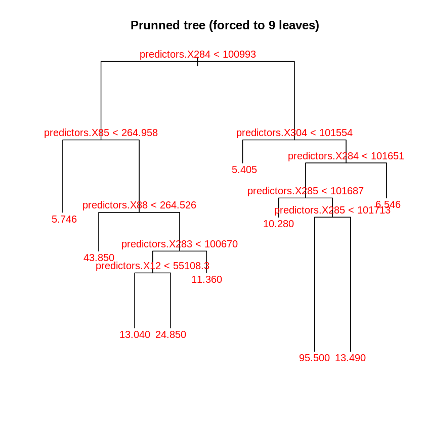

```
yhat_2 <- predict(prune.opt_rain_reg_2, newdata = df_2[indtest2, -c(1)])
```

```
prune.opt_rain_reg_test_2 <- df_2[indtest2, "lluvia2"]
```

```
plot(yhat_2, prune.opt_rain_reg_test_2)
```

```
title(main = "Pruned tree - test set")
```

```
test_reg2_test <- sqrt(mean((yhat_2 - prune.opt_rain_reg_test_2)^2))
```

```
mtext(text = paste("RMSE =", round(test_reg2_test, 3)), side = 3)
```

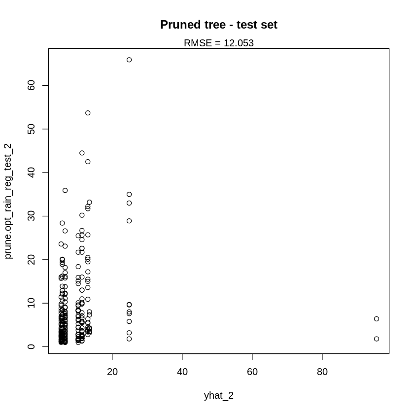

```
#Al ser un caso de regresion en vez de un caso de clasificacion el error se mide en RMSE en vez de en
```

```
#la accuracy de alguno de los valores de la matriz de confusion
```

```
cat("Error del árbol optimo en regresion para el dataSet df_2 en el subset de test es:",test_reg2_test)
```

```
#Mucho mas alto que en el caso anterior
```

```
Error del árbol optimo en regresion para el dataSet df_2 en el subset de test es: 12.05264
```

```
## Incluir el codigo y responder a la cuestion
```

```
cat("Accuracy for test para el caso de clasificacion:",acc.t_class_tree)
```

```
cat("\n")
```

```
cat("Error regresion para el dataSet df_1 test es:",rmse.test_reg1_test)
```

```
cat("\n")
```

```
cat("Error regresion para el dataSet df_2 (siempre lluvia) en test es:",test_reg2_test)
```

```
cat("\n")
```

```
Accuracy for test para el caso de clasificacion: 0.8552
Error regresion para el dataSet df_1 test es: 4.853716
Error regresion para el dataSet df_2 (siempre lluvia) en test es: 12.05264
```

```
#Por un lado es dificil comprar el caso de clasificacion binario con el caso de regresión.
```

```
#En el caso de clasificacion la exigencia de la prediccion es mucho menor.
```

```
#En cuanto a los casos de regresion, el error es mas bajo cuando se consideran todos los dias tanto los de lluvia,
```

```
#como los de no lluvia. Esto puede ser debido a que los dias de no lluvia aportan menos error y luego
```

```
#al hacer la media de error se beneficia de esos dias
```

```
#Por el contrario, en el caso de regresión solo para los dias de lluvia el error es mas del doble que en el caso
```

```
#anterior. Posiblemente por una acumulacion de error en cada caso que no se da en el caso anterior por contemplar
```

```
#los dias de no lluvia.
```

```
## Random forests (2.5 puntos)
```

```
A continuación vamos a realizar el mismo ejercicio pero sustituyendo árboles individuales por random forests, empleando para ello en este ejercicio la técnica de “bagging”. Empecemos con el evento ocurrencia. Para estimar cuál sería el tamaño óptimo de nuestro random forest, prueba bosques de hasta 1000 árboles (utiliza la función randomForest) y plotea los errores “Out-Of-Bag” (OOB). ¿Con cuántos árboles te quedarías?
```

## Random forests (2.5 puntos)

A continuación vamos a realizar el mismo ejercicio pero sustituyendo árboles individuales por random forests, empleando para ello en este ejercicio la técnica de “bagging”. Empecemos con el evento ocurrencia. Para estimar cuál sería el tamaño óptimo de nuestro random forest, prueba bosques de hasta 1000 árboles (utiliza la función randomForest) y plotea los errores “Out-Of-Bag” (OOB). ¿Con cuántos árboles te quedarías?

```
library(randomForest)
```

```
#Caso 1. Arboles de clasificacion
```

```
rf1 = randomForest(y.occ ~., df.occ, subset = indtrain, ntree=1000)
```

```
plot(rf1$err.rate[, 1], type = "l", xlab = "no. trees", ylab = "OOB error")
```

```
grid()
```

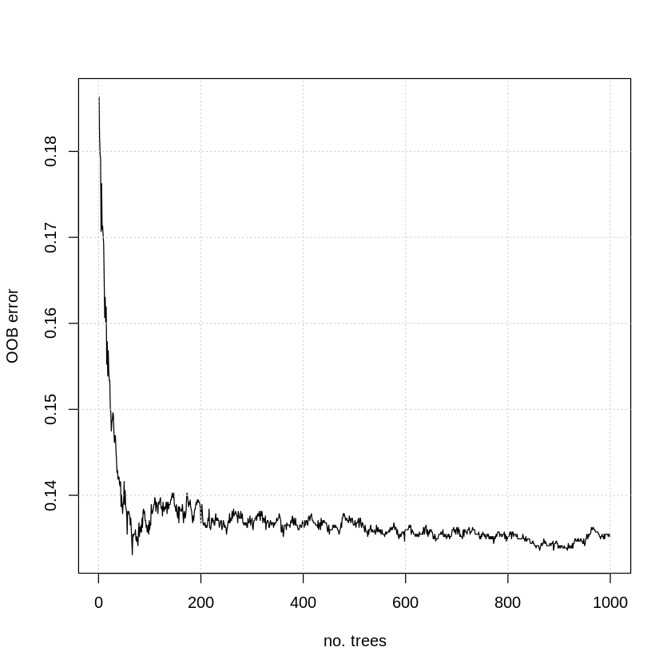

```
cat("El modelo se quedaria con:",which.min(rf1$err.rate[, 1]),"arboles")
```

```
# Por que es el valor minimo y además es un valor pequeño dentro del rango 0-1000 arboles
```

```
# ese minimo es aceptado
```

```
El modelo se quedaria con: 66 arboles
```

```
***Nota:*** Hemos visto en la teoría que además del número de árboles, el otro parámetro a ajustar en los random forests es el número de predictores que se consideran en cada nodo para el splitting. En este ejemplo utlizaremos los valores típicos; n−−√ en problemas de clasificación y n/3 en problemas de predicción (siendo n el número total de predictores disponibles).
```

```
Utiliza el bosque de tamaño óptimo parar predecir la ocurrencia en el test, y conserva la predicción.
```

```
Seguidamente, tal y como hicimos con los árboles individuales, vamos a crear dos random forests para la cantidad, uno que se entrene sobre todo el dataset de train y otro que se entrene sólo sobre los días de lluvia (en el train). De nuevo, tendrás que estimar cuál es el número óptimo de árboles en cada uno de ellos (prueba bosques de hasta 1000 árboles). ¿Qué tamaños óptimos obtienes?
```

*Nota:* Hemos visto en la teoría que además del número de árboles, el otro parámetro a ajustar en los random forests es el número de predictores que se consideran en cada nodo para el splitting. En este ejemplo utlizaremos los valores típicos; n−−√ en problemas de clasificación y n/3 en problemas de predicción (siendo n el número total de predictores disponibles).

Utiliza el bosque de tamaño óptimo parar predecir la ocurrencia en el test, y conserva la predicción.

Seguidamente, tal y como hicimos con los árboles individuales, vamos a crear dos random forests para la cantidad, uno que se entrene sobre todo el dataset de train y otro que se entrene sólo sobre los días de lluvia (en el train). De nuevo, tendrás que estimar cuál es el número óptimo de árboles en cada uno de ellos (prueba bosques de hasta 1000 árboles). ¿Qué tamaños óptimos obtienes?

```
#Para el caso de ocurrencia al ser un problema d clasifiacion usaria sqrt(n) para el numero de predictores.
```

[output not shown]

```
rf1_opt = randomForest(y.occ ~., df.occ,
```

```
                       subset = indtrain, ntree=which.min(rf1$err.rate[, 1]), mtry=sqrt(38) )
```

```
x
```

```
pred <- predict(rf1_opt, df.occ[indtest, ])
```

```
acc.best_rf <- sum(diag(table(pred, df.occ$y.occ[indtest]))) / length(indtest)
```

```
cat("Accuracy con Random Forest para el caso de clasificación:",acc.best_rf)
```

```
Accuracy con Random Forest para el caso de clasificación: 0.8744
```

```
#caso 2. Regresion sobre el dataSet completo train/test
```

```
rf2 <- randomForest(lluvia1 ~., df_1 , subset = indtrain, ntree=1000)
```

```
plot(rf2$mse, type = "l", xlab = "no. trees", ylab = "OOB error")
```

```
grid()
```

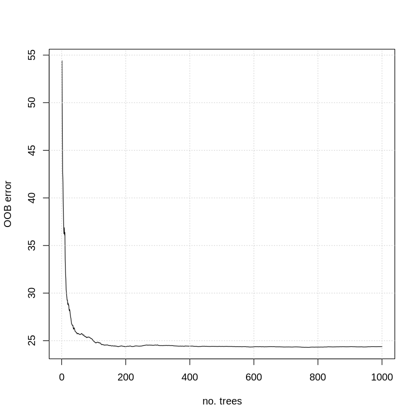

```
x
```

```
#Para una mejor visualizacion
```

```
plot(rf2$mse, type = "l", xlab = "no. trees", ylab = "OOB error",xlim=c(150,1000),ylim=c(24.3,25))
```

```
grid()
```

```
points(175,24.37,col="red")
```

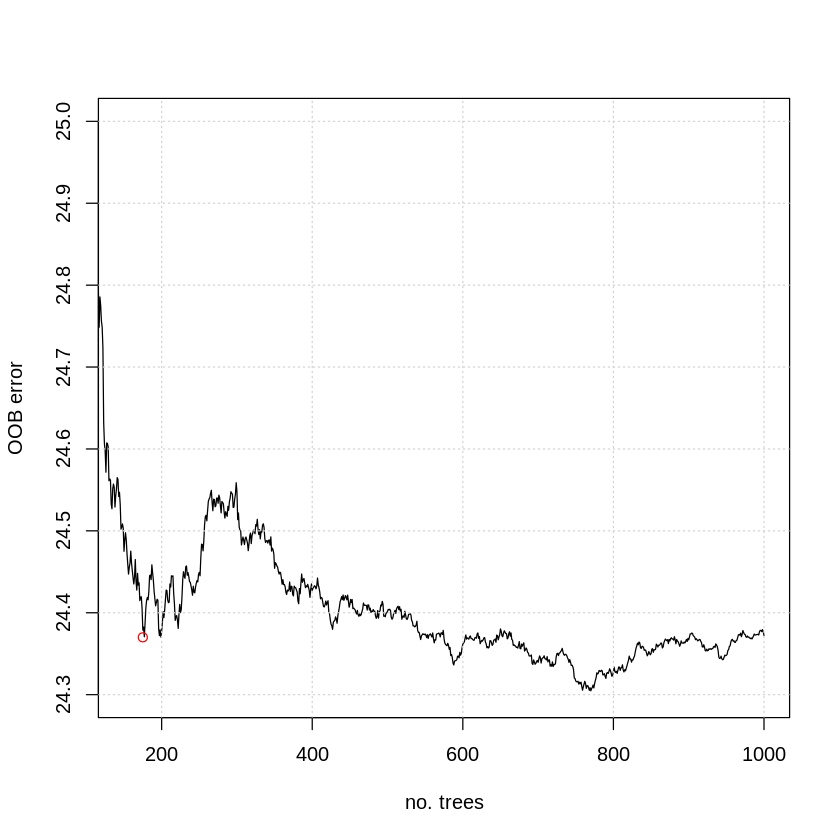

```
x
```

```
cat("El modelo se quedaria con:",which.min(rf2$mse),"arboles")
```

```
#Por que es el valor minimo y además es un valor pequeño dentro del rango 0-1000 arboles
```

```
cat("\n")
```

[output not shown]

```
cat("Se seleccionan:",175,"arboles")
```

```
#Y al ser un caso de regresion se seleccionan n/3 predictores = 38/3 se redondea a 13.
```

```
El modelo se quedaria con: 770 arboles
Se seleccionan: 175 arboles
```

```
rf2_opt = randomForest(lluvia1 ~., df_1, subset = indtest,
```

```
                       ntree=175, mtry=13 )
```

```
x
```

```
pred_2 <- predict(rf2_opt, df_1[indtest, ])
```

```
rmse.test_rf_2 <- sqrt(mean((pred_2 - df_1$lluvia1[indtest])^2))
```

```
cat("Accuracy con Random Forest para el caso de regresion (test)",rmse.test_rf_2)
```

```
Accuracy con Random Forest para el caso de regresion (test) 2.09359
```

```
#caso 3. Regresion sobre el dataSet de dias de lluvia train/test
```

```
rf3 <- randomForest(lluvia2 ~., df_2 , subset = indtrain2, ntree=1000)
```

```
plot(rf3$mse, type = "l", xlab = "no. trees", ylab = "OOB error")
```

```
grid()
```

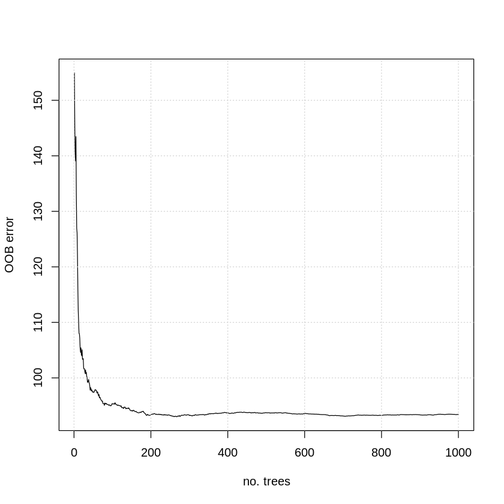

```
#Para una mejor visualizacion
```

```
plot(rf3$mse, type = "l", xlab = "no. trees", ylab = "OOB error",xlim=c(0,1000),ylim=c(82,98))
```

```
grid()
```

```
points(265,93,col="red")
```

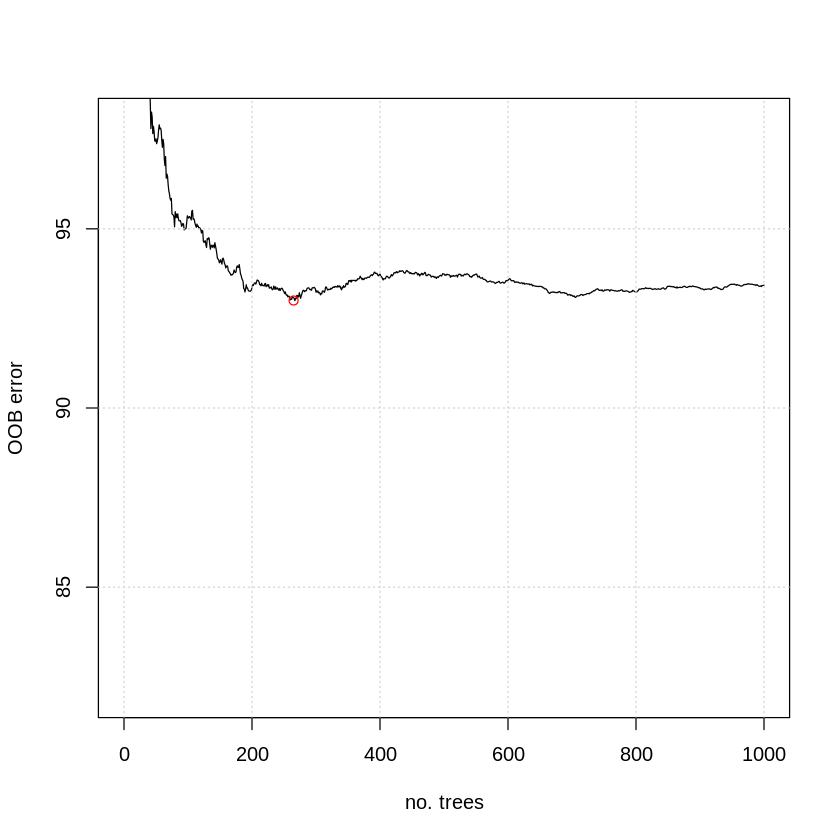

```
x
```

```
cat("El modelo se quedaria con:",which.min(rf2$mse),"arboles")
```

```
#Por que es el valor minimo y además es un valor pequeño dentro del rango 0-1000 arboles
```

```
cat("\n")
```

```
cat("Se seleccionan:",265,"arboles")
```

```
#Pero parece que un random fores de 265 arboles puede ser un buen trade-off.
```

[output not shown]

```
rf3_opt = randomForest(lluvia2 ~., df_2, subset = indtest2,
```

```
                       ntree=265, mtry=13 )
```

```
x
```

```
pred_3 <- predict(rf3_opt, df_2[indtest2, ])
```

```
rmse.test_rf_3 <- sqrt(mean((pred_3 - df_2$lluvia2[indtest2])^2))
```

```
cat("Accuracy con Random Forest para el caso de regresion en dias de lluvia (test)",rmse.test_rf_3)
```

```
Accuracy con Random Forest para el caso de regresion en dias de lluvia (test) 3.868023
```

```
## Incluir el codigo y responder a la cuestion
```

```
Utiliza los bosques óptimos encontrados para predecir la cantidad en el test, y conserva las predicciones obtenidas.
```

```
Construye las predicciones completas (ocurrencia×cantidad) de test y valídalas en función de las mismas métricas utilizadas en el apartado anterior.
```

```
Pregunta: Compara estos resultados con los obtenidos para árboles individuales. ¿Qué conclusiones obtienes de la comparación entre árboles individuales y random forests?
```

Utiliza los bosques óptimos encontrados para predecir la cantidad en el test, y conserva las predicciones obtenidas.

Construye las predicciones completas (ocurrencia×cantidad) de test y valídalas en función de las mismas métricas utilizadas en el apartado anterior.

Pregunta: Compara estos resultados con los obtenidos para árboles individuales. ¿Qué conclusiones obtienes de la comparación entre árboles individuales y random forests?

```
x
```

```
## Incluir el codigo y responder a la cuestion
```

```
cat("Accuracy para el caso de clasificación (test):",acc.t_class_tree)
```

```
cat("\n")
```

```
cat("Accuracy con Random Forest optimo para el caso de clasificación (test):",acc.best_rf)
```

```
cat("\n")
```

```
cat("RSME del árbol optimo para el caso de regresion (test)",rmse.test_reg1_test)
```

```
cat("\n")
```

```
cat("RSME con Random Forest optimo para el caso de regresion (test)",rmse.test_rf_2)
```

```
cat("\n")
```

```
cat("RSME del árbol  para el caso de regresion en dias de lluvia :",test_reg2_test)
```

```
cat("\n")
```

```
cat("RSME con Random Forest optimo para el caso de regresion en dias de lluvia (test)",rmse.test_rf_3)
```

```
Accuracy para el caso de clasificación (test): 0.8552
Accuracy con Random Forest optimo para el caso de clasificación (test): 0.8744
RSME del árbol optimo para el caso deregresion (test) 4.853716
RSME con Random Forest optimo para el caso de regresion (test) 2.09359
RSME del árbol  para el caso de regresion en dias de lluvia : 12.05264
RSME con Random Forest optimo para el caso de regresion en dias de lluvia (test) 3.868023
```

[output not shown]

```
cat("Para el caso de clasificacion la mejora es del:",100*(acc.best_rf-acc.t_class_tree)/acc.t_class_tree,"%")
```

```
cat("\n")
```

```
cat("Para el caso de regresion la mejora es de un",100*(rmse.test_reg1_test-rmse.test_rf_2)/rmse.test_reg1_test,"%")
```

```
cat("\n")
```

```
cat("Para el caso de regresion sobre dias de lluvia la mejora es de un",100*(test_reg2_test-rmse.test_rf_3)/test_reg2_test,"%")
```

```
cat("\n")
```

[output not shown]

```
Para el caso de clasificacion la mejora es del: 2.245089 %
Para el caso de regresion la mejora es de un 56.86625 %
Para el caso de regresion sobre dias de lluvia la mejora es de un 67.90724 %
```

```
## Modelos lineales generalizados (GLMs) (1.5 puntos)
```

```
Usaremos a continuación GLMs para el mismo problema abordado en los apartados anteriores. Como ya hemos visto en otras sesiones, debemos utilizar la familia binomial con función de enlace logit (regresión logística) para clasificación y la familia Gamma con función de enlace logarítmica para la cantidad.
```

```
Comenzamos con el modelo para la ocurrencia.
```

```
Una vez tenemos el modelo, lo utilizamos para predecir en el test. Tendremos que convertir la predicción probabilística obtenida en binaria (considera un umbral 0.5).
```

```
A continuación, ajustamos el modelo de cantidad. Para ello tenemos que seleccionar previamente los días de lluvia (la familia Gamma sólo acepta valores positivos).
```

```
Utilizamos el modelo obtenido para predecir la cantidad en el test.
```

```
De nuevo, multiplicamos la ocurrencia por la cantidad para obtener la predicción completa en el test y la validamos en función de las métricas de validación que utilizamos para CART y random forests.
```

```
Pregunta: Compara estos resultados con los obtenidos para CART y random forests. ¿Qué conclusiones obtienes?
```

## Modelos lineales generalizados (GLMs) (1.5 puntos)

Usaremos a continuación GLMs para el mismo problema abordado en los apartados anteriores. Como ya hemos visto en otras sesiones, debemos utilizar la familia binomial con función de enlace logit (regresión logística) para clasificación y la familia Gamma con función de enlace logarítmica para la cantidad.

Comenzamos con el modelo para la ocurrencia.

Una vez tenemos el modelo, lo utilizamos para predecir en el test. Tendremos que convertir la predicción probabilística obtenida en binaria (considera un umbral 0.5).

A continuación, ajustamos el modelo de cantidad. Para ello tenemos que seleccionar previamente los días de lluvia (la familia Gamma sólo acepta valores positivos).

Utilizamos el modelo obtenido para predecir la cantidad en el test.

De nuevo, multiplicamos la ocurrencia por la cantidad para obtener la predicción completa en el test y la validamos en función de las métricas de validación que utilizamos para CART y random forests.

Pregunta: Compara estos resultados con los obtenidos para CART y random forests. ¿Qué conclusiones obtienes?

[output not shown]

```
## k nearest neighbors (k-NN) (1.5 puntos)
```

```
La última de las técnicas a utilizar será vecinos cercanos (ten en cuenta que en este caso ya no tendremos que predecir por separado ocurrencia y cantidad). Comenzaremos por una versión de k-NN en la que sólo se considere el vecino más cercano (utiliza la función knn.reg del paquete FNN).
```

```
Nota: Recuerda que en la técnica k-NN es muy importante pre-procesar adecuadamente (estandarizar) los predictores.
```

```
Como vimos en su día, el único parámetro a ajustar en la técnica k-NN es k (número de vecinos). Utilizaremos el paquete caret para encontrar el k óptimo en nuestro problema. Para ello, considera una cross-validación con 10 folds sobre el dataset de train y barre todos los k impares desde 1 a 50.
```

```
Utiliza este k óptimo para predecir en el test.
```

```
Valida las dos predicciones (con k=1 y con k=óptimo) en el test, en función de las medidas que se han ido utilizando en los apartados anteriores.
```

```
Pregunta: ¿Qué diferencias obtienes entre las dos versiones utilizadas de la técnica k-NN? ¿A qué se deben?
```

## k nearest neighbors (k-NN) (1.5 puntos)

La última de las técnicas a utilizar será vecinos cercanos (ten en cuenta que en este caso ya no tendremos que predecir por separado ocurrencia y cantidad). Comenzaremos por una versión de k-NN en la que sólo se considere el vecino más cercano (utiliza la función knn.reg del paquete FNN).

Nota: Recuerda que en la técnica k-NN es muy importante pre-procesar adecuadamente (estandarizar) los predictores.

Como vimos en su día, el único parámetro a ajustar en la técnica k-NN es k (número de vecinos). Utilizaremos el paquete caret para encontrar el k óptimo en nuestro problema. Para ello, considera una cross-validación con 10 folds sobre el dataset de train y barre todos los k impares desde 1 a 50.

Utiliza este k óptimo para predecir en el test.

Valida las dos predicciones (con k=1 y con k=óptimo) en el test, en función de las medidas que se han ido utilizando en los apartados anteriores.

Pregunta: ¿Qué diferencias obtienes entre las dos versiones utilizadas de la técnica k-NN? ¿A qué se deben?

[output not shown]

```
## Conclusiones generales (2 puntos)
```

```
A la vista de los resultados obtenidos, argumenta razonadamente qué técnica o técnicas serían las mejores para la predicción de lluvia en Lisboa. Justifica tu respuesta.
```

## Conclusiones generales (2 puntos)

A la vista de los resultados obtenidos, argumenta razonadamente qué técnica o técnicas serían las mejores para la predicción de lluvia en Lisboa. Justifica tu respuesta.

```
## occurrence prediction for test
```

```
A continuación, ajustamos el modelo de cantidad. Para ello tenemos que seleccionar previamente los días de lluvia (la familia Gamma sólo acepta valores positivos).
```

A continuación, ajustamos el modelo de cantidad. Para ello tenemos que seleccionar previamente los días de lluvia (la familia Gamma sólo acepta valores positivos).

```
## GLM for amount
```

```
Utilizamos el modelo obtenido para predecir la cantidad en el test.
```

Utilizamos el modelo obtenido para predecir la cantidad en el test.

```
## amount prediction for test
```

```
De nuevo, multiplicamos la ocurrencia por la cantidad para obtener la predicción completa en el test y la validamos en función de las métricas de validación que utilizamos para CART y random forests.
```

De nuevo, multiplicamos la ocurrencia por la cantidad para obtener la predicción completa en el test y la validamos en función de las métricas de validación que utilizamos para CART y random forests.

```
# final prediction for test
```

```
# validation
```

```
**Pregunta:** Compara estos resultados con los obtenidos para CART y random forests. ¿Qué conclusiones obtienes?
```

**Pregunta:** Compara estos resultados con los obtenidos para CART y random forests. ¿Qué conclusiones obtienes?

```
## k nearest neighbors (k-NN)
```

```
### (1.5 puntos)
```

```
La última de las técnicas a utilizar será la k-NN (ten en cuenta que en este caso ya no tendremos que predecir por separado ocurrencia y cantidad). Comenzaremos por una versión de k-NN en la que sólo se considere el vecino más cercano (utiliza la función *knn.reg* del paquete *FNN*).
```

```
**Nota:** Recuerda que en la técnica k-NN es muy importante pre-procesar adecuadamente (estandarizar) los predictores.
```

## k nearest neighbors (k-NN)

### (1.5 puntos)

La última de las técnicas a utilizar será la k-NN (ten en cuenta que en este caso ya no tendremos que predecir por separado ocurrencia y cantidad). Comenzaremos por una versión de k-NN en la que sólo se considere el vecino más cercano (utiliza la función *knn.reg* del paquete *FNN*).

**Nota:** Recuerda que en la técnica k-NN es muy importante pre-procesar adecuadamente (estandarizar) los predictores.

```
## prediction for test (with k = 1)
```

```
Como vimos en su día, el único parámetro a ajustar en la técnica k-NN es k (número de vecinos). Utilizaremos el paquete *caret* para encontrar el k óptimo en nuestro problema. Para ello, considera una cross-validación con 10 folds sobre el dataset de train y barre todos los k impares desde 1 a 50.
```

Como vimos en su día, el único parámetro a ajustar en la técnica k-NN es k (número de vecinos). Utilizaremos el paquete *caret* para encontrar el k óptimo en nuestro problema. Para ello, considera una cross-validación con 10 folds sobre el dataset de train y barre todos los k impares desde 1 a 50.

```
library(caret)
```

```
Utiliza este *k* óptimo para predecir en el test.
```

Utiliza este *k* óptimo para predecir en el test.

```
# prediction for test (with optimum k)
```

```
Valida las dos predicciones (con *k=1* y con *k=óptimo*) en el test, en función de las medidas que se han ido utilizando en los apartados anteriores.
```

Valida las dos predicciones (con *k=1* y con *k=óptimo*) en el test, en función de las medidas que se han ido utilizando en los apartados anteriores.

```
# validation
```

```
**Pregunta:** ¿Qué diferencias obtienes entre las dos versiones utilizadas de la técnica k-NN? ¿A qué se deben?
```

**Pregunta:** ¿Qué diferencias obtienes entre las dos versiones utilizadas de la técnica k-NN? ¿A qué se deben?

```
## Conclusiones generales
```

```
### (2 puntos)
```

```
A la vista de los resultados obtenidos, argumenta razonadamete qué técnica o técnicas serían las mejores para la predicción de lluvia en Lisboa. Justifica tu respuesta.
```

## Conclusiones generales

### (2 puntos)

A la vista de los resultados obtenidos, argumenta razonadamete qué técnica o técnicas serían las mejores para la predicción de lluvia en Lisboa. Justifica tu respuesta.